# Class Example Task 2

Ben Woodruff

5/4/2021

## Task 2 Background

In this document, we will be exploring the following models.

1. $f_0(L; a,b) = \frac{1}{b-a}$ with $-\infty < a < L < b < \infty$ (and 0 otherwise)
2. $f_1(L; h,a) = \frac{1}{\sqrt{2\pi a}}e^{-\frac{(x-h)^2}{2a}}$ with $h>0$, $a>0$, and $−\infty<L<\infty$
3. $f_2(L; h,a,b) = \frac{b^a}{\Gamma(a)}(L-h)^{a-1}e^{-b(L-h)}$ with $a>0$, $b>0$, and $L\geq h$ (and 0 otherwise)

### Model $f_0$

Let’s examine the first model, $f_0$. The variable $a$ controls the starting point of the domain of the function, and similarly $b$ is the end point. The function is constant. Let’s plot a couple representatives below.

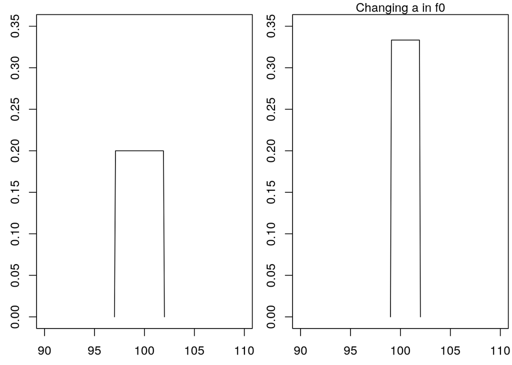

```r
f0 <- function(L,a=0,b=1){
  # Make sure a < b when using this function.

  out <- rep(-1,length(L))
  out[(L <= a)] <- 0
  out[(a < L) & (L < b)] <- 1/(b-a) + 0*L[(a < L) & (L < b)]
  out[(L >=b)] <-0

  return(out)
}

b <- 102
a1 <- 97
L1 <- seq(a1,b,0.1)
y1 <- f0(L1,a1,b)

par(mfrow=c(1,2),mar=c(2.5,2.5,1,0.25))
plot(L1,y1,type='l',xlim=c(90,110), ylim=c(0,0.35))

a2 <- 99
L2 <- seq(a2,b,0.1)
y2 <- f0(L2,a2,b)

plot(L2,y2,type='l',xlim=c(90,110), ylim=c(0,0.35))
mtext('Changing a in f0', side = 3, line = 0)
```

In the two plots above we chose $b=102$, and changed $a$ from 97 to 99. Making $a$ closer to $b$ causes the graph to be narrow and higher. We can similarly see what happens as we change $b$, which we will do in the plots below.

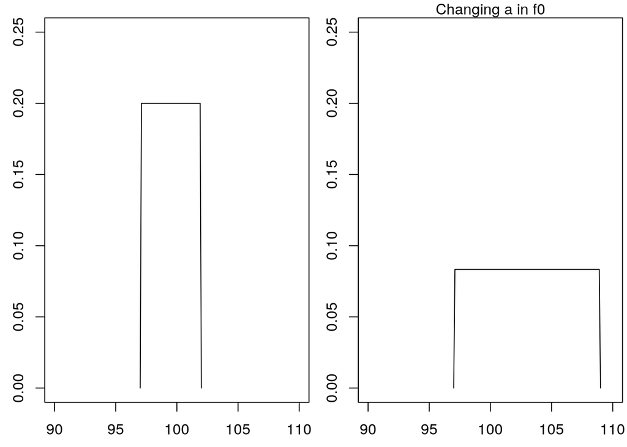

```r
b1 <- 102
a <- 97
L1 <- seq(a,b1,0.1)
y1 <- f0(L1,a,b1)

par(mfrow=c(1,2),mar=c(2.5,2.5,1,0.25))
plot(L1,y1,type='l',xlim=c(90,110), ylim=c(0,0.25))

b2 <- 109
L2 <- seq(a,b2,0.1)
y2 <- f0(L2,a,b2)

plot(L2,y2,type='l',xlim=c(90,110), ylim=c(0,0.25))
mtext('Changing a in f0', side = 3, line = 0)
```

In the plot above we fixed $a=97$ and then changed $b$ from 102 to 109. Increasing $b$ caused the graph to be wider and shorter.

### Model $f_1$

We now examine the second model, $f_1(L; h,a) = \frac{1}{\sqrt{2\pi a}}e^{-\frac{(x-h)^2}{2a}}$ with $h>0$, $a>0$, and $−\infty<L<\infty$. This model produces a mound shaped curve. The output of the function is all positive. The values increase until $h$, and then decrease after $h$. The variable $a$ controls how sharply the mound spikes upwards before dropping. Let’s view this in several examples.

In the pictures below, we’ll fix $a=2$ and then change $h$ from 99 to 102. Notice that the value of $h$ just causes the model to recenter the graph around the values $h$.

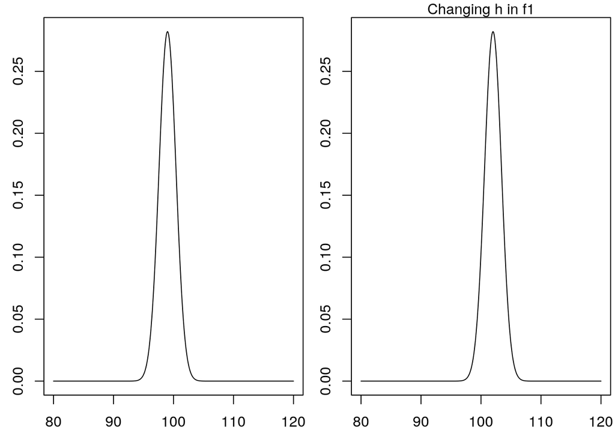

```r
f1 <- function(L,h=0,a=1){
#Make sure h > 0 and a > 0.

1/sqrt(2*pi*a)*exp(-(L-h)^2/(2*a))
}

a <- 2
L <- seq(80,120,0.1)
h1 <- 99
y1 <- f1(L,h1,a)

par(mfrow=c(1,2),mar=c(2.5,2.5,1,0.25))
plot(L,y1,type='l',xlim=c(80,120))

h2 <- 102
y2 <- f1(L,h2,a)

plot(L,y2,type='l',xlim=c(80,120))
mtext('Changing h in f1', side = 3, line = 0)
```

Now we’ll fix $h=101$, and change the value of $a$ from 2 to 1, in the graph below, and focus on the fact that a smaller value for $a$ causes the graph to spike more rapidly (reaches a higher value over a smaller width).

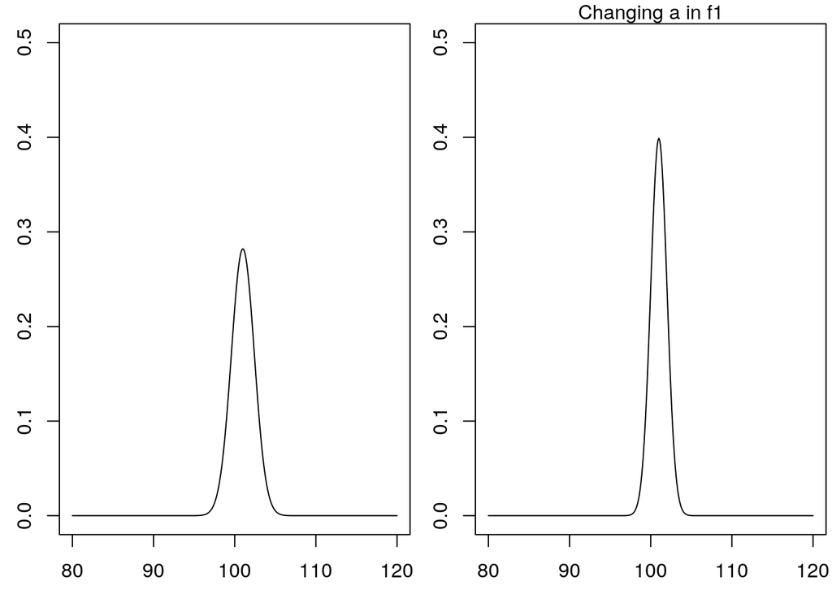

```r
a1 <- 2
L <- seq(80,120,0.1)
h <- 101
y1 <- f1(L,h,a1)

par(mfrow=c(1,2),mar=c(2.5,2.5,1,0.25))
plot(L,y1,type='l',xlim=c(80,120), ylim=c(0,0.5))

a2 <- 1
y2 <- f1(L,h,a2)

plot(L,y2,type='l',xlim=c(80,120), ylim=c(0,0.5))
mtext('Changing a in f1', side = 3, line = 0)
```

In summary, the parameter $h$ tells us where the peak of the mound is at, while the variable $a$ controld how tall peak gets to (as well as how wide the mound is).

## Model $f_2$

Recall the final model we promised to explore is $f_2(L; h,a,b) = \frac{b^a}{\Gamma(a)}(L-h)^{a-1}e^{-b(L-h)}$$ with $a>0$, $b>0$, and $L\geq h$ (and 0 otherwise).